# Coral and Microplastics

- Home
- Background
- Preprocessing
- Model Building
- Results/Discussion
- References

# MODEL BUILDING

These two functions define the right-hand sides of a coupled ODE system for coral cover $C(t)$ and microplastics $P(t)$. The coral equation starts with logistic growth $rC(1- \frac{C}{K})$, a standard population-recovery model that captures rapid recovery at low cover and slowing growth as coral approaches a carrying capacity $K$. Logistic recovery models are widely used for coral cover dynamics, and in the Great Barrier Reef many researchers explicitly fit a logistic recovery framework to reef monitoring data and report an estimated carrying capacity around 80% for some non-stressful recovery periods [5].

Microplastics affect coral through the inhibition term $-{\alpha}PC$, which assumes microplastic stress increases with pollution level and impacts more coral when more coral is present. This is a simplified way to represent experimentally observed microplastic impacts on coral health and performance.

The microplastics equation $\frac{dP}{dt} = I - {\delta}P - {\beta}CP$ includes a constant input $I$, a first-order loss term δP which represents degredation, and an interaction loss term ${\beta}CP$ representing coral related trapping proportional to both coral cover and microplastic level. Finally, the with Allee model modifies coral growth by multiplying the logistic term by $(\frac{C}{A} -1)$, a classic strong Allee effect formulation that makes growth negative below a threshold A, reflecting recovery failure when coral cover is too low [6].

The coral population parameters K, which represents corals carrying capacity, and r, which represents corals intrinsic growth rate, were obtained from literature source [5]. This source measured and calculated the disturbance and dynamics of coral cover on the great barrier reef. They had a reported carrying capacity and intrinsic growth rate that we were able to utilize for simulation. The $\alpha$ parameter represents how strongly microplastics reduce coral growth, and was estimated because literature does not provide a single universal growth inhibition constant usable across reefs. Thus, it treated as an estimated or sensitivity parameter in this model, chosen to give realistic qualitative dynamics. This was an educated estimate with sources [7] and [8] used as a reference. The $\delta$ parameter represents the environmental degradation/export rate of microplastics per year. Marine plastics and microplastics are widely reported to be persistent and to degrade slowly in the environment with ranges from 100-1000 years for degredation [9]. For this model we aired on the optimistic side assigning a value for $\delta$ corresponding to 100 year degredation rates. The $\beta$ parameter represents coral reefs acting as sinks for microplastics, suggests reef building corals can remove a measurable fraction of bioavailable microplastics from reef waters each year. Although this number is small, recent papers have indicated that this value is worth measuring and was thus worth including in the differential equation systems. This value was estimated similarly to the $\alpha$ parameter using the sources listed below [10]. Additionally, the $A$ parameter represents the allee threshold which was obtained from the literature listed below [5]. Finally, the parameter $I$ represents the microplastic input rate which was calculated using mean surface microplastic concentrations and was scaled as described in the upcomming cells.

```python
# Coral population parameters
K = 0.80 # K is the carrying capacity
r = 0.04 # intrinsic coral recovery/growth rate (per year)
alpha = 0.01 # how strongly microplastics reduce coral growth.

# Microplastic parameters
delta = 0.01 # environmental degradation/export rate of microplastics (per year)
beta = 0.001 # coral related trapping/removal rate (per year per coral-cover unit).
A = 0.2 # Allee threshold

I = 0.02 # microplastic input rate.


# Simulation Parameters
t_span = (0, 100)
t_eval = np.linspace(*t_span, 2000)



def coral_microplastics_no_allee(t, y, I, K, r, alpha, delta, beta):
    """Coral–microplastics ODE model WITHOUT an Allee effect."""
    # Unpack the state variables
    C, P = y
    C, P = safe_nonnegative(C, P)

    # Coral dynamics:
    #   r*C*(1 - C/K) = logistic growth toward carrying capacity K
    #   -alpha*P*C    = growth inhibition that increases with microplastics and coral cover
    dCdt = r * C * (1 - C / K) - alpha * P * C

    # Microplastics dynamics:
    #   +I            = constant input (pollution entering the system)
    #   -delta*P      = slow degradation/export
    #   -beta*C*P     = coral trapping/removal
    dPdt = I - delta * P - beta * C * P

    return [dCdt, dPdt]


def coral_microplastics_with_allee(t, y, I, K, r, alpha, delta, beta, A):
    """Coral–microplastics ODE model WITH an Allee effect in coral growth. """
    C, P = y
    C, P = safe_nonnegative(C, P)

    # Coral dynamics with Allee effect:
    #   r*C*(1 - C/K)*(C/A - 1) = logistic growth modified to include a critical threshold A
    #   -alpha*P*C              = microplastics inhibition
    dCdt = r * C * (1 - C / K) * (C / A - 1.0) - alpha * P * C

    # Microplastics dynamics
    dPdt = I - delta * P - beta * C * P

    return [dCdt, dPdt]
```

```python
# Check coral with no allee
test_states = [
    (0.0, 0.0),     # no coral, no plastic
    (0.1, 0.0),     # low coral, no plastic
    (0.5, 0.0),     # moderate coral, no plastic
    (0.5, 1.0),     # coral + plastics
    (0.9, 1.0),     # above K-ish (should shrink)
    (0.1, 5.0),     # heavy plastic load
]

for C, P in test_states:
    dC1, dP1 = coral_microplastics_no_allee(0, [C, P], I, K, r, alpha, delta, beta)
    dC2, dP2 = coral_microplastics_with_allee(0, [C, P], I, K, r, alpha, delta, beta, A)
    print(f"(C,P)=({C:.2f},{P:.2f})  noAllee: dC={dC1:.4f}, dP={dP1:.4f} | withAllee: dC={dC2:.4f}, dP={dP2:.4f}")
```

```
(C,P)=(0.00,0.00)  noAllee: dC=0.0000, dP=0.0200 | withAllee: dC=-0.0000, dP=0.0200
(C,P)=(0.10,0.00)  noAllee: dC=0.0035, dP=0.0200 | withAllee: dC=-0.0018, dP=0.0200
(C,P)=(0.50,0.00)  noAllee: dC=0.0075, dP=0.0200 | withAllee: dC=0.0112, dP=0.0200
(C,P)=(0.50,1.00)  noAllee: dC=0.0025, dP=0.0095 | withAllee: dC=0.0062, dP=0.0095
(C,P)=(0.90,1.00)  noAllee: dC=-0.0135, dP=0.0091 | withAllee: dC=-0.0248, dP=0.0091
(C,P)=(0.10,5.00)  noAllee: dC=-0.0015, dP=-0.0305 | withAllee: dC=-0.0068, dP=-0.0305
```

```python
# Check coral with allee

P_test = 0.0
for C_test in [A*0.9, A*1.1]:
    dC = coral_microplastics_with_allee(0, [C_test, P_test], 0.0, K, r, alpha, delta, beta, A)[0]
    print(f"C={C_test:.3f} relative to A={A:.3f} -> dCdt={dC:.6f}")
```

```
C=0.180 relative to A=0.200 -> dCdt=-0.000558
C=0.220 relative to A=0.200 -> dCdt=0.000638
```

Microplastic concentrations are reported in physical units (particles m⁻³) and vary widely across sampling locations, which can lead to instability and poor parameter interpretability when used directly in differential equation models. To address this, microplastic concentrations are rescaled into a dimensionless variable $P$ by dividing by a representative high-value concentration. This concentration is defined here as the 90th percentile of observed data. This scaling allows model parameters to operate on comparable numerical scales and makes simulation results easier to interpret across regions and scenarios.

```python
def scale_microplastics(concentration_series, quantile=0.90):
    """Scale raw microplastic concentrations into a dimensionless variable P."""

    # Convert the input data to a Series and compute the 90th percentile
    P_scale = float(pd.Series(concentration_series).quantile(quantile))

    # Check that the scaling value is valid and positive.
    if not np.isfinite(P_scale) or P_scale <= 0:
        raise ValueError("P_scale is invalid; check microplastics data for non-positive values.")

    # Return the scaled microplastics concentration P and the scaling constant used
    return concentration_series / P_scale, P_scale

# check
test_data = pd.Series([1, 2, 3, 4, 5])

P_scaled, P_scale = scale_microplastics(test_data, quantile=0.80)

print("P_scale:", P_scale)
print("Scaled values:")
print(P_scaled)
```

```
P_scale: 4.2
Scaled values:
0    0.238095
1    0.476190
2    0.714286
3    0.952381
4    1.190476
dtype: float64
```

compute_region_coral_cover() extracts a data driven coral starting condition $C0$ from the most recent AIMS year and converts it into a fraction that can be used for the logistic growth model. compute_region_microplastics_scaled() builds a dimensionless microplastics starting condition $P0$ by scaling raw concentrations using a quantile. Finally, build_initial_conditions() ensures that the model only simulate regions where there is both coral and microplastics data.

```python
def compute_region_coral_cover(coral_df):
    """Compute region-specific initial coral cover values (C0)."""
    # Identify the most recent year in the dataset
    latest_year = coral_df["YEAR_CODE"].max()

    # Subset to the latest year and make a copy
    latest = coral_df.loc[coral_df["YEAR_CODE"] == latest_year].copy()

    # Assign a GBR region to each row based on latitude
    latest.loc[:, "GBR_region"] = latest["LATITUDE"].apply(assign_gbr_region)

    # Mean coral cover per region
    region_coral_fraction = latest.groupby("GBR_region")["COVER"].mean() / 100.0

    # Sort the index
    return region_coral_fraction.sort_index()


def compute_region_microplastics_scaled(micro_df, quantile=0.90):
    """Compute region-specific initial microplastic values (P0), scaled to be dimensionless."""
    # Compute scaling constant from the raw concentration distribution
    P_scale = float(micro_df["Microplastics"].quantile(quantile))

    # Validate scaling constant
    if not np.isfinite(P_scale) or P_scale <= 0:
        raise ValueError("P_scale is invalid; check microplastics data for non-positive or missing values.")

    # Make copy
    micro = micro_df.copy()

    # Assign GBR regions using the same latitude
    micro.loc[:, "GBR_region"] = micro["Latitude"].apply(assign_gbr_region)

    # Create a dimensionless microplastics variable
    micro.loc[:, "P_scaled"] = micro["Microplastics"] / P_scale

    # Compute mean scaled microplastics per region
    region_scaled = micro.groupby("GBR_region")["P_scaled"].mean().sort_index()

    return region_scaled, P_scale


def build_initial_conditions(region_coral, region_micro_scaled):
    """ Build region-specific initial conditions y0 = [C0, P0] for the ODE solver. """
    # Identify overlapping regions across both datasets
    common_regions = sorted(set(region_coral.index) & set(region_micro_scaled.index))

    # If there is no overlap, the model can't build initial conditions
    if len(common_regions) == 0:
        raise ValueError("No overlapping regions between coral and microplastics data.")

    # Build y0 dictionary
    y0_by_region = {
        reg: [float(region_coral.loc[reg]), float(region_micro_scaled.loc[reg])]
        for reg in common_regions}
    return y0_by_region
```

```python
# check regional coral cover
# Toy coral dataset (2 years, multiple latitudes)
toy_coral = pd.DataFrame({
    "YEAR_CODE": [2023, 2023, 2024, 2024, 2024],
    "LATITUDE":  [-13,  -18,  -13,  -18,  -22],   # N, C, N, C, S
    "COVER":     [10,   20,   30,   40,   50]     # percent
})

region_coral = compute_region_coral_cover(toy_coral)
print(region_coral)
```

```
GBR_region
Central GBR     0.4
Northern GBR    0.3
Southern GBR    0.5
Name: COVER, dtype: float64
```

```python
# check regional microplastics scaled
toy_micro = pd.DataFrame({
    "Latitude":      [-13, -18, -22],   # N, C, S
    "Microplastics": [1.0, 2.0, 3.0]    # raw units
})

region_micro_scaled, P_scale = compute_region_microplastics_scaled(toy_micro, quantile=1.0)

print("P_scale:", P_scale)
print(region_micro_scaled)
```

```
P_scale: 3.0
GBR_region
Central GBR     0.666667
Northern GBR    0.333333
Southern GBR    1.000000
Name: P_scaled, dtype: float64
```

```python
# check initial conditions
# Use outputs from the toy tests above
y0_by_region = build_initial_conditions(region_coral, region_micro_scaled)
print(y0_by_region)
```

```
{'Central GBR': [0.4, 0.6666666666666666], 'Northern GBR': [0.3, 0.3333333333333333], 'Southern GBR': [0.5, 1.0]}
```

This function provides reusable and easily accessible set up around scipy.integrate.solve_ivp to run the coral microplastics model for any region and parameter set. By passing the ODE system, initial conditions, input rate, and parameters as arguments, the function keeps the numerical solver separate from the ecological model itself.

```python
def run_simulation(model_fun, y0, I, params, t_span, t_eval):
    """Run a numerical simulation of the coral–microplastics ODE model for a single region
    and a single microplastic input rate."""

    # Solve the system of differential equations
    sol = solve_ivp(
        # Wrap the model function so I and parameters are passed cleanly
        fun=lambda t, y: model_fun(t, y, I, **params),
        t_span=t_span,
        # Initial coral cover and microplastic concentration
        y0=y0,
        t_eval=t_eval,
        method="RK45",

        # tolerances for accuracy
        rtol=1e-6,
        atol=1e-9)
    return sol

# check
# Example parameter dicts
params_no = dict(K=K, r=r, alpha=alpha, delta=delta, beta=beta)

y0_test = [0.3, 0.5]   # (C0, P0)
I_test = 0.02

sol = run_simulation(coral_microplastics_no_allee, y0_test, I_test, params_no, t_span, t_eval)

print("success:", sol.success)
print("status:", sol.status)
print("n time points:", len(sol.t))
print("y shape:", sol.y.shape)
print("first state:", sol.y[:, 0])
print("last state:", sol.y[:, -1])
```

```
success: True
status: 0
n time points: 2000
y shape: (2, 2000)
first state: [0.3 0.5]
last state: [0.53303691 1.41262364]
```

This function takes the simulation outputs stored as solutions_by_region[region] and makes a row per region figure with coral cover on the left and microplastics on the right for each region. It draws horizontal reference lines for K and A if required.

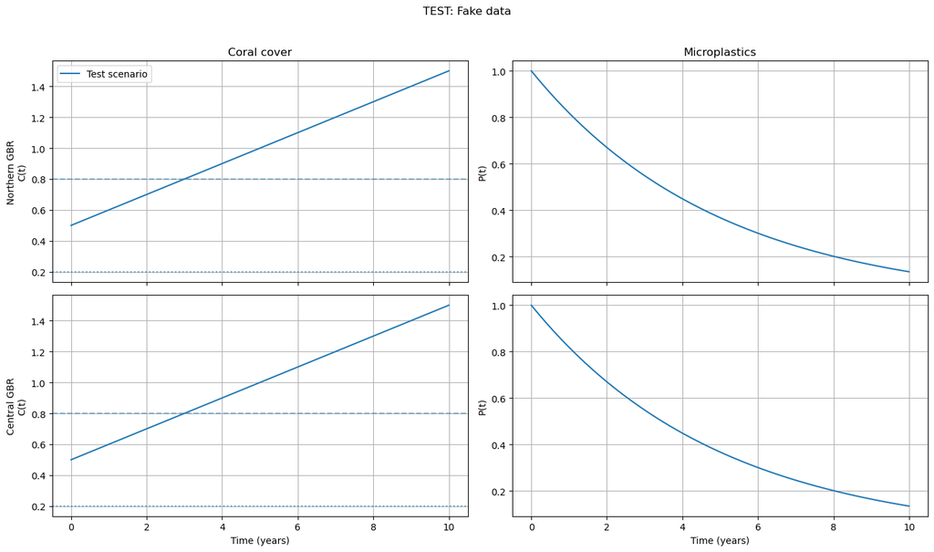

```python
def plot_region_results(solutions_by_region, labels, K, A=None, title=""):
    """ Plot ODE results for multiple GBR regions."""
    # Convert dict keys into a stable list of region names (plot order)
    regions = list(solutions_by_region.keys())
    n_regions = len(regions)

    # Create a grid with one row per region and two columns:
    # left = coral cover C(t), right = microplastics P(t)
    fig, axes = plt.subplots(
        n_regions, 2,
        figsize=(14, 4 * n_regions),
        sharex=True)
    fig.suptitle(title, y=1.02)

    # If there's only one region, matplotlib returns axes as shape (2,)
    if n_regions == 1:
        axes = np.array([axes])

    for row, region in enumerate(regions):
        sols = solutions_by_region[region]

        # If passed a single solution instead of a list, wrap it.
        if not isinstance(sols, (list, tuple)):
            sols = [sols]

        # Ensure we have the right number of labels for the number of solutions.
        if (labels is None) or (len(labels) != len(sols)):
            scenario_labels = [f"Scenario {i+1}" for i in range(len(sols))]
        else:
            scenario_labels = labels

        # Plot each scenario for this region
        for sol, lab in zip(sols, scenario_labels):
            axes[row, 0].plot(sol.t, sol.y[0], label=lab)  # C(t)
            axes[row, 1].plot(sol.t, sol.y[1], label=lab)  # P(t)

        # Reference lines on coral plot
        axes[row, 0].axhline(K, linestyle="--", alpha=0.5)
        if A is not None:
            axes[row, 0].axhline(A, linestyle=":", alpha=0.7)

        # Axis labels + grids
        axes[row, 0].set_ylabel(f"{region}\nC(t)")
        axes[row, 1].set_ylabel("P(t)")
        axes[row, 0].grid(True)
        axes[row, 1].grid(True)

    # Legend
    axes[0, 0].legend()

    # Shared x-label on bottom
    axes[-1, 0].set_xlabel("Time (years)")
    axes[-1, 1].set_xlabel("Time (years)")

    # Column titles
    axes[0, 0].set_title("Coral cover")
    axes[0, 1].set_title("Microplastics")

    plt.tight_layout()
    plt.show()

# check
# Create a fake solution object
class FakeSol:
    def __init__(self):
        self.t = np.linspace(0, 10, 50)
        self.y = np.vstack([
            0.5 + 0.1 * self.t,      # C(t)
            1.0 * np.exp(-0.2*self.t)  # P(t)
        ])

fake_sol = FakeSol()

solutions_by_region = {
    "Northern GBR": [fake_sol],
    "Central GBR": [fake_sol]}

plot_region_results(
    solutions_by_region,
    labels=["Test scenario"],
    K=0.8,
    A=0.2,
    title="TEST: Fake data")
```

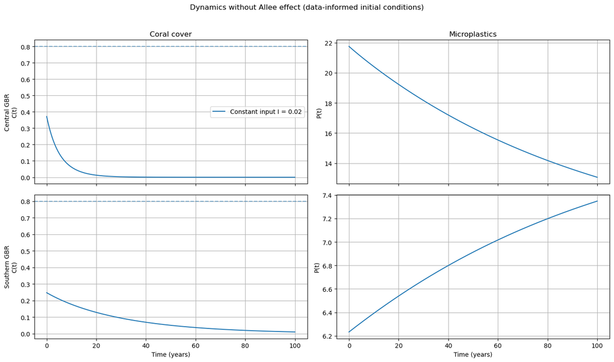

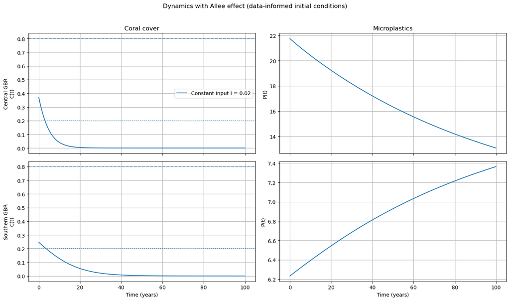

```python
# Load and clean datasets using helper functions
coral_df = load_coral_data("mmp_hc_sc_a_by_site.csv")
micro_df = load_microplastics_data("Marine_Microplastics_WGS84_6672910164286251904.csv")

# Compute region-specific initial conditions from data
region_coral = compute_region_coral_cover(coral_df)
region_micro_scaled, P_scale = compute_region_microplastics_scaled(micro_df, quantile=0.90)
y0_by_region = build_initial_conditions(region_coral, region_micro_scaled)

I_raw = 0.02 # same I parameter as above
# scale it to match the dimensionless P used in the ODE
I_scaled = I_raw / P_scale  # scaled input so it is consistent with P_scaled

# Bundle parameters for each model version
params_no_allee = dict(K=K, r=r, alpha=alpha, delta=delta, beta=beta)
params_with_allee = dict(K=K, r=r, alpha=alpha, delta=delta, beta=beta, A=A)

# Run no allee simulation
solutions_no = {}
for reg, y0 in y0_by_region.items():
    y0_run = [y0[0], y0[1]]
    # Run one simulation using your solve_ivp wrapper
    sol = run_simulation(
        model_fun=coral_microplastics_no_allee,
        y0=y0_run,
        I=I_scaled,
        params=params_no_allee,
        t_span=t_span,
        t_eval=t_eval)

    # Store as a list
    solutions_no[reg] = [sol]

# Plot results no allee
plot_region_results(
    solutions_by_region=solutions_no,
    labels=[f"Constant input I = {I_raw:.2f}"],
    K=K,
    title="Dynamics without Allee effect (data-informed initial conditions)")


# Run simulations with allee
solutions_a = {}
for reg, y0 in y0_by_region.items():
    y0_run = [y0[0], y0[1]]
    sol = run_simulation(
        model_fun=coral_microplastics_with_allee,
        y0=y0_run,
        I=I_scaled,
        params=params_with_allee,
        t_span=t_span,
        t_eval=t_eval)

    solutions_a[reg] = [sol]

# Plot results with allee
plot_region_results(
    solutions_by_region=solutions_a,
    labels=[f"Constant input I = {I_raw:.2f}"],
    K=K,
    A=A,
    title="Dynamics with Allee effect (data-informed initial conditions)")
```